# Horseweed emergence in Nebraska

## Lincoln

### Model

I am using a Weibull function with three parameters. Notice that the upper limit is locked at 100.

I have used the same model for all locations.

```r
model2 <- drm(emergence ~ GDD, trt,
              fct = W1.3(fixed = c(NA, 100, NA),
                         names = c("slope", "upper", "ed50")),
              data = lincoln)
```

### Figure

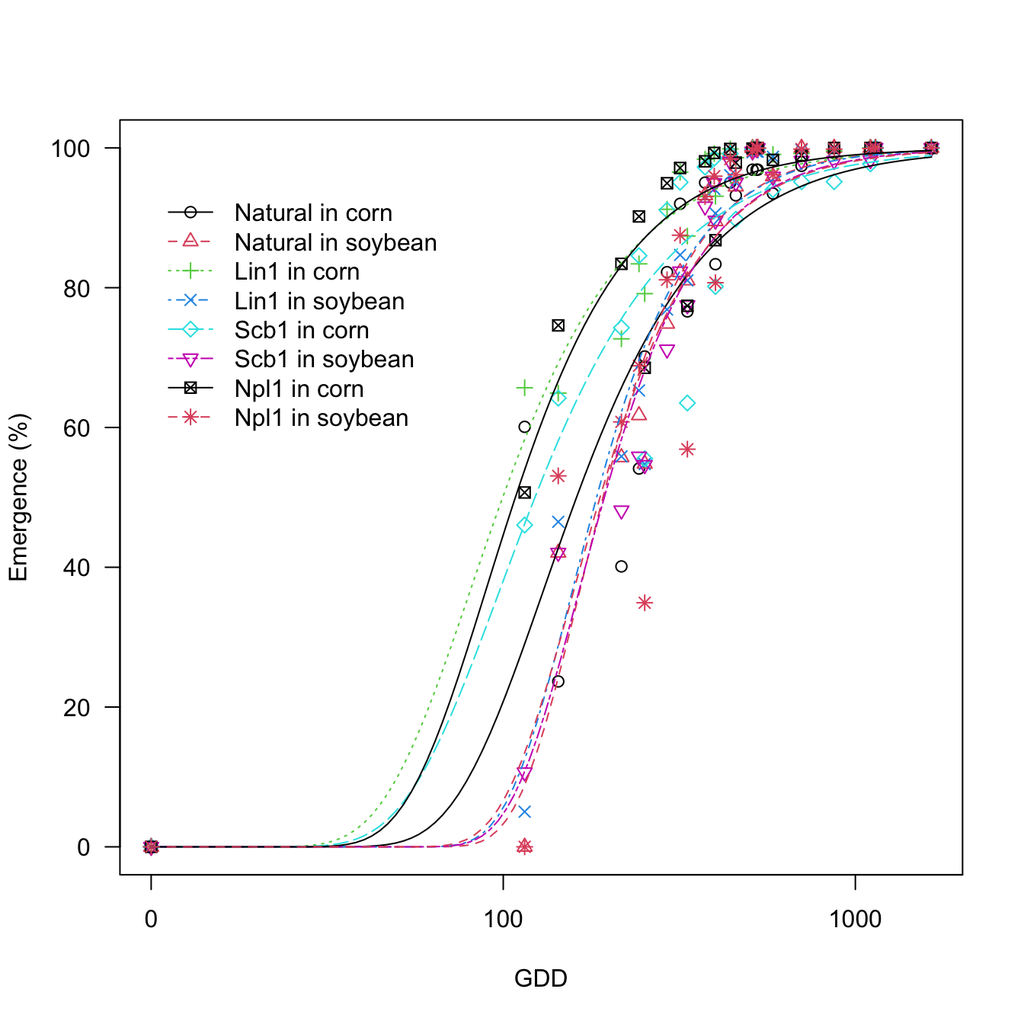

### Model parameters

```r
summary(model2)
```

| term | curve | estimate | std.error | statistic | p.value |
| --- | --- | --- | --- | --- | --- |
| slope | Natural in corn | -1.7067 | 0.1319 | -12.9352 | 0 |
| slope | Natural in soybean | -2.4504 | 0.1675 | -14.6313 | 0 |
| slope | Lin1 in corn | -1.7442 | 0.2099 | -8.3111 | 0 |
| slope | Lin1 in soybean | -2.3356 | 0.1598 | -14.6126 | 0 |
| slope | Scb1 in corn | -1.6009 | 0.1565 | -10.2278 | 0 |
| slope | Scb1 in soybean | -2.243 | 0.1576 | -14.2355 | 0 |
| slope | Npl1 in corn | -1.9107 | 0.2329 | -8.2035 | 0 |
| slope | Npl1 in soybean | -2.1585 | 0.1421 | -15.1872 | 0 |
| ed50 | Natural in corn | 130.2669 | 7.9665 | 16.3519 | 0 |
| ed50 | Natural in soybean | 165.2338 | 6.137 | 26.9241 | 0 |

[output cut: 6 more lines]

### EDs

```r
ED(model2, c(10, 50, 90), interval = "delta")
```

| Term | Estimate | Std. Error | Lower | Upper |
| --- | --- | --- | --- | --- |
| e:Lin1 in corn:10 | 50.0618 | 8.1054 | 34.1586 | 65.965 |
| e:Lin1 in corn:50 | 99.6392 | 9.046 | 81.8904 | 117.3879 |
| e:Lin1 in corn:90 | 293.4206 | 25.7344 | 242.9282 | 343.913 |
| e:Lin1 in soybean:10 | 110.1011 | 6.1642 | 98.0067 | 122.1956 |
| e:Lin1 in soybean:50 | 184.088 | 6.172 | 171.9781 | 196.1979 |
| e:Lin1 in soybean:90 | 412.3977 | 22.4287 | 368.3915 | 456.404 |
| e:Natural in corn:10 | 79.9091 | 7.4254 | 65.3401 | 94.4781 |
| e:Natural in corn:50 | 161.4735 | 8.0605 | 145.6584 | 177.2887 |
| e:Natural in corn:90 | 486.9553 | 33.6513 | 420.9297 | 552.981 |
| e:Natural in soybean:10 | 117.5659 | 6.3398 | 105.1269 | 130.0049 |

[output cut: 14 more lines]

### Emergence comparisons

A t-test is made for each treatment at 90%, 50%, and 10%. You can compare 10 with 90% also. Also, you can compare any number between 1 and 100. I am using 10, 50, and 90% because it is the most common and you can tell a nice story.

#### Comparison of 90% emergence

```r
EDcomp(model2, c(90,90), type = "absolute")
```

| Comparison | Estimate | Std. Error | t-value | p-value |
| --- | --- | --- | --- | --- |
| Lin1 in corn/Lin1 in soybean:90/90 | 0.7115 | 0.0734 | -3.9291 | 0.0001 |
| Lin1 in corn/Natural in corn:90/90 | 0.6026 | 0.0673 | -5.9071 | 0 |
| Lin1 in corn/Natural in soybean:90/90 | 0.7088 | 0.0721 | -4.0378 | 0.0001 |
| Lin1 in corn/Npl1 in corn:90/90 | 1.0114 | 0.1253 | 0.0908 | 0.9276 |
| Lin1 in corn/Npl1 in soybean:90/90 | 0.6511 | 0.0678 | -5.1424 | 0 |
| Lin1 in corn/Scb1 in corn:90/90 | 0.7353 | 0.0903 | -2.933 | 0.0034 |
| Lin1 in corn/Scb1 in soybean:90/90 | 0.6543 | 0.0674 | -5.1325 | 0 |
| Lin1 in soybean/Natural in corn:90/90 | 0.8469 | 0.0745 | -2.0558 | 0.04 |
| Lin1 in soybean/Natural in soybean:90/90 | 0.9963 | 0.0746 | -0.0499 | 0.9602 |
| Lin1 in soybean/Npl1 in corn:90/90 | 1.4215 | 0.1465 | 2.8772 | 0.0041 |

[output cut: 18 more lines]

#### Comparison of 50% emergence

```r
EDcomp(model2, c(50,50), type = "absolute")
```

| Comparison | Estimate | Std. Error | t-value | p-value |
| --- | --- | --- | --- | --- |
| Lin1 in corn/Lin1 in soybean:50/50 | 0.5413 | 0.0524 | -8.7574 | 0 |
| Lin1 in corn/Natural in corn:50/50 | 0.6171 | 0.0639 | -5.9898 | 0 |
| Lin1 in corn/Natural in soybean:50/50 | 0.5192 | 0.0501 | -9.6047 | 0 |
| Lin1 in corn/Npl1 in corn:50/50 | 0.9205 | 0.1078 | -0.737 | 0.4613 |
| Lin1 in corn/Npl1 in soybean:50/50 | 0.5292 | 0.0513 | -9.1788 | 0 |
| Lin1 in corn/Scb1 in corn:50/50 | 0.8099 | 0.0918 | -2.0703 | 0.0386 |
| Lin1 in corn/Scb1 in soybean:50/50 | 0.5146 | 0.0501 | -9.683 | 0 |
| Lin1 in soybean/Natural in corn:50/50 | 1.1401 | 0.0686 | 2.0429 | 0.0413 |
| Lin1 in soybean/Natural in soybean:50/50 | 0.9593 | 0.0447 | -0.9092 | 0.3635 |
| Lin1 in soybean/Npl1 in corn:50/50 | 1.7007 | 0.1382 | 5.0723 | 0 |

[output cut: 18 more lines]

#### Comparison of 10% emergence

```r
EDcomp(model2, c(10,10), type = "absolute")
```

| Comparison | Estimate | Std. Error | t-value | p-value |
| --- | --- | --- | --- | --- |
| Lin1 in corn/Lin1 in soybean:10/10 | 0.4547 | 0.0779 | -7.0006 | 0 |
| Lin1 in corn/Natural in corn:10/10 | 0.6265 | 0.117 | -3.1938 | 0.0014 |
| Lin1 in corn/Natural in soybean:10/10 | 0.4258 | 0.0727 | -7.9016 | 0 |
| Lin1 in corn/Npl1 in corn:10/10 | 0.867 | 0.1847 | -0.7205 | 0.4713 |
| Lin1 in corn/Npl1 in soybean:10/10 | 0.4637 | 0.0797 | -6.7297 | 0 |
| Lin1 in corn/Scb1 in corn:10/10 | 0.8614 | 0.1784 | -0.7771 | 0.4373 |
| Lin1 in corn/Scb1 in soybean:10/10 | 0.4416 | 0.0765 | -7.297 | 0 |
| Lin1 in soybean/Natural in corn:10/10 | 1.3778 | 0.1495 | 2.5277 | 0.0116 |
| Lin1 in soybean/Natural in soybean:10/10 | 0.9365 | 0.0728 | -0.8722 | 0.3833 |
| Lin1 in soybean/Npl1 in corn:10/10 | 1.9067 | 0.2846 | 3.1854 | 0.0015 |

[output cut: 18 more lines]

## North Platte

### Model

```r
model3 <- drm(emergence ~ GDD, trt,
              fct = W1.3(fixed = c(NA, 100, NA),
                         names = c("slope", "upper", "ed50")),
              data = north_platte)
```

### Figure

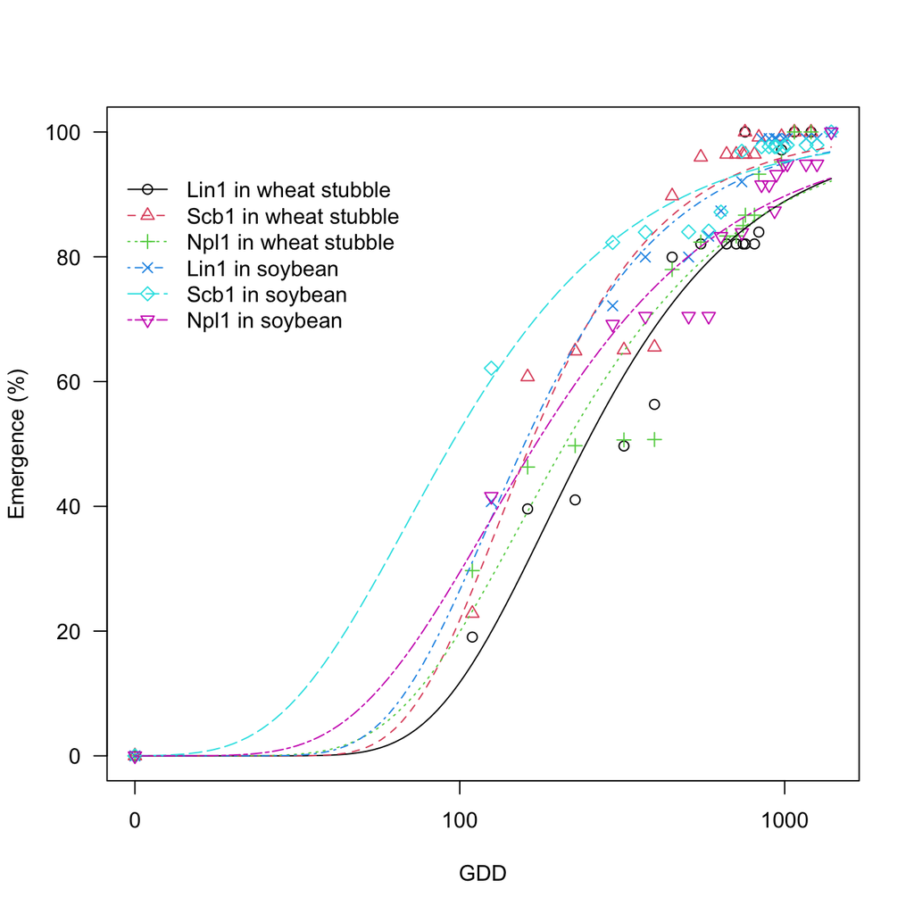